# Köppen-Geiger climate matching of plant pests against Norway

Method, data and worked examples behind kg_viewer

Author

Daniel Flø

Published

October 21, 2026

```r
library(DBI)
library(RSQLite)
library(dplyr)
library(tidyr)
library(ggplot2)
library(terra)
library(rnaturalearth)

DB <- "../kg_climate.db"
q  <- function(sql, params = NULL) {
  con <- dbConnect(SQLite(), DB, flags = SQLITE_RO)
  on.exit(dbDisconnect(con))
  dbGetQuery(con, sql, params = params)
}

build   <- with(q("SELECT * FROM buildInfo"), setNames(value, key))
legend  <- q("SELECT * FROM kgLegend ORDER BY kgValue")
kg_cols <- setNames(legend$hex, legend$kgCode)
species <- q("SELECT * FROM species")

source("../R/support.R")        # data-support levels and tints, shared with the app
source("../R/support_map.R")
source("../R/support_bins.R")

theme_set(theme_minimal(base_size = 12) +
            theme(panel.grid.minor = element_blank(),
                  plot.title.position = "plot"))
```

## 1 Purpose

To establish, a pest that arrives in Norway has to survive and reproduce in the climate it lands in. Pest risk ranking models therefore ask an establishment question about climate suitability, for example EST1 in FinnPRIO (Heikkilä et al. 2016). Assessors usually answer it by hand, from distribution maps and expert knowledge.

`kg_viewer` supplies the evidence for that judgement. It does this in a consistent and documented way that can be repeated for many species. For each pest it answers three questions:

1. Which Köppen-Geiger climate classes does the pest demonstrably occupy?
2. How much of non-alpine Norway lies in those classes today?
3. How does that share change under a high-emission scenario for 2041–2070?

The current build (2026-10-14) covers **63 species** and **66,863 occupied 1 km cells**.

## 2 Where this sits among climate-matching methods

Pest risk assessments use climate in roughly three ways, from simplest to most demanding:

| Approach | Example | Needs | Output |
| --- | --- | --- | --- |
| Climate classification overlay | Köppen-Geiger classes of the known range vs. the risk area | Occurrences | Shared classes, area share |
| Process-based niche models | CLIMEX (Sutherst and Maywald 1985) | Occurrences plus physiology (thresholds, diapause) | Ecoclimatic index |
| Correlative species distribution models | MaxEnt, GLM/GAM ensembles (Elith and Leathwick 2009) | Occurrences, background, covariates | Continuous suitability |

Overlaying Köppen-Geiger classes is the standard first screen in EU pest categorisation. EFSA’s Plant Health Panel compares the classes in a pest’s range with those in the EU (EFSA Panel on Plant Health (PLH) 2018). The method is coarse, but it is transparent, cheap, and easy to defend in an assessment text, and it works for species with only tens of records, where SDMs are unreliable. Baker et al. (2000) discuss its strengths and pitfalls for non-indigenous pests.

`kg_viewer` keeps this approach and fixes several weaknesses of how it is usually applied:

- **Resolution.** It uses the 1 km Beck et al. maps (Beck et al. 2023) instead of the 0.5° Kottek map (Kottek et al. 2006). Coastal and mountain gradients, which shape Norway’s climate, are resolved.
- **Data cleaning.** GBIF records are filtered and screened with CoordinateCleaner (Zizka et al. 2019) before any class is counted.
- **Thresholded occupancy.** A class counts only with enough independent cells (rule below), not because of a single record. EFSA practice is unthresholded.
- **Explicit uncertainty.** A resampling test reports whether the Norway-relevant class list would change with half the data. Each occupied class also carries a data-support level (its cell count), shown directly on the map.
- **Future climate.** The same classes are evaluated against Norway’s 2041–2070 SSP5-8.5 map from the same, internally consistent dataset.

## 3 Data

### 3.1 Climate: Beck et al. 2023

The maps cover 1901–2099 at 1 km. Future periods use an ensemble of CMIP6 models constrained by observed warming (Beck et al. 2023). This build uses Beck et al. 2023, Scientific Data, 1991-2020 for classifying occurrences and Norway, and 2041-2070, SSP5-8.5 for Norway’s future profile.

Norway is measured by area (km², with cell area shrinking with latitude). The alpine/polar classes ET, EF are excluded because practically no plant pests establish there, so all shares are of *non-alpine* Norway.

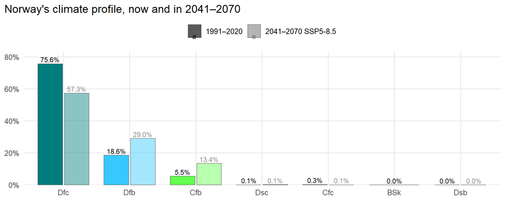

Share of non-alpine mainland Norway per Köppen-Geiger class. Classes under 0.1 % are labelled but barely visible.

```r
no <- bind_rows(
  q("SELECT * FROM kgNorway")       |> mutate(period = "1991–2020"),
  q("SELECT * FROM kgNorwayFuture") |> mutate(period = "2041–2070 SSP5-8.5")
) |>
  left_join(legend, by = "kgCode") |>
  mutate(kgCode = reorder(kgCode, -proportion, max))

ggplot(no, aes(kgCode, proportion, fill = kgCode, alpha = period)) +
  geom_col(position = position_dodge(0.8), width = 0.75, colour = "grey30", linewidth = 0.2) +
  geom_text(aes(label = scales::percent(proportion, 0.1)),
            position = position_dodge(0.8), vjust = -0.3, size = 3) +
  scale_fill_manual(values = kg_cols, guide = "none") +
  scale_alpha_manual(values = c(1, 0.45), name = NULL) +
  scale_y_continuous(labels = scales::percent, expand = expansion(c(0, 0.1))) +
  labs(x = NULL, y = NULL, title = "Norway's climate profile, now and in 2041–2070") +
  theme(legend.position = "top")
```

Norway today is dominated by the cold-summer boreal class **Dfc**. Under SSP5-8.5 it gives way to the warm-summer **Dfb** and the oceanic **Cfb**. A pest whose occupied classes include Dfb or Cfb therefore gains ground in Norway over time. One restricted to warmer classes does not, because those classes do not appear in Norway at all.

```r
shift <- full_join(q("SELECT kgCode, proportion AS now FROM kgNorway"),
                   q("SELECT kgCode, proportion AS future FROM kgNorwayFuture"),
                   by = "kgCode") |>
  mutate(across(c(now, future), ~ coalesce(.x, 0)),
         change = future - now) |>
  left_join(select(legend, kgCode, kgLabel), by = "kgCode") |>
  arrange(desc(now))

knitr::kable(transmute(shift, Class = kgCode, Climate = kgLabel,
                       `1991–2020` = scales::percent(now, 0.01),
                       `2041–2070` = scales::percent(future, 0.01),
                       `Change (pp)` = sprintf("%+.1f", 100 * change)))
```

| Class | Climate | 1991–2020 | 2041–2070 | Change (pp) |
| --- | --- | --- | --- | --- |
| Dfc | Cold, no dry season, cold summer | 75.63% | 57.32% | -18.3 |
| Dfb | Cold, no dry season, warm summer | 18.56% | 29.04% | +10.5 |
| Cfb | Temperate, no dry season, warm summer | 5.47% | 13.43% | +8.0 |
| Cfc | Temperate, no dry season, cold summer | 0.25% | 0.07% | -0.2 |
| Dsc | Cold, dry summer, cold summer | 0.07% | 0.14% | +0.1 |
| Dsb | Cold, dry summer, warm summer | 0.01% | 0.00% | -0.0 |
| BSk | Arid, steppe, cold | 0.00% | 0.00% | -0.0 |

### 3.2 Occurrences: GBIF

Records come from the GBIF occurrence search API via `rgbif`, using the accepted backbone key of each species. Only records with coordinates, no geospatial issue and status `PRESENT` are kept. Cleaning is fully recorded in `buildInfo`:

| Step | Setting |
| --- | --- |
| Basis of record dropped | FOSSIL_SPECIMEN, LIVING_SPECIMEN |
| Establishment means dropped | MANAGED |
| Max. coordinate uncertainty | 10000 m (missing kept) |
| CoordinateCleaner tests | capitals, centroids, equal, gbif, institutions, zeros |

After cleaning, records are thinned to one per 1 km raster cell. This is the unit everything is counted in. It removes much of the sampling bias that comes from many records at one well-visited site, though not all of it (see Limitations).

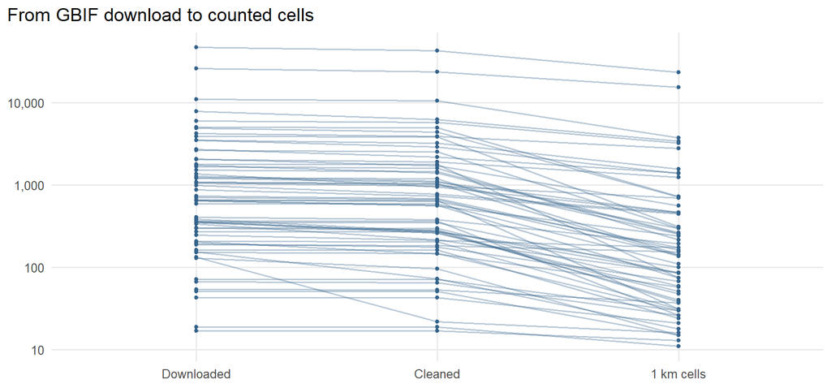

Records per species at each pipeline stage (log scale). Each line is one species.

```r
funnel <- species |>
  select(eppoCode, Downloaded = nDownloaded, Cleaned = nClean, `1 km cells` = nCells) |>
  pivot_longer(-eppoCode, names_to = "stage") |>
  mutate(stage = factor(stage, c("Downloaded", "Cleaned", "1 km cells")))

ggplot(funnel, aes(stage, value, group = eppoCode)) +
  geom_line(alpha = 0.35, colour = "steelblue4") +
  geom_point(size = 1, colour = "steelblue4") +
  scale_y_log10(labels = scales::label_comma()) +
  labs(x = NULL, y = NULL, title = "From GBIF download to counted cells")
```

```r
tot <- colSums(species[, c("nDownloaded", "nClean", "nCells")])
```

Across all species, 160,085 downloaded records become 145,303 after cleaning, which thin to 66,863 cells.

## 4 From occurrences to evidence

### 4.1 The occupancy rule

A class is **occupied** by a species when it holds

$$n_k \ge 5 \quad\text{and}\quad n_k \ge 0.1\,\% \times \sum_j n_j$$

The rule is implemented as the SQL view `occupiedKgClasses`. The raw counts in `pestKgClasses` remain unfiltered, so any other rule can be applied downstream.

### 4.2 Norway overlap

The headline number is the share of non-alpine Norway lying in the occupied classes:

$$\text{pctNorway} = \sum_{k \in \text{occupied}} \frac{A_{\text{Norway},k}}{A_{\text{Norway}}}$$

```r
overlap <- q("
  SELECT s.eppoCode, s.scientificName, s.nCellsNonAlpine AS cells,
         s.uncertainty, s.classStability,
         COALESCE((SELECT SUM(n.proportion) FROM occupiedKgClasses o
                   JOIN kgNorway n USING (kgCode) WHERE o.eppoCode = s.eppoCode), 0) AS now,
         COALESCE((SELECT SUM(f.proportion) FROM occupiedKgClasses o
                   JOIN kgNorwayFuture f USING (kgCode) WHERE o.eppoCode = s.eppoCode), 0) AS future
  FROM species s") |>
  mutate(uncertainty = factor(uncertainty, c("low", "medium", "high")))
```

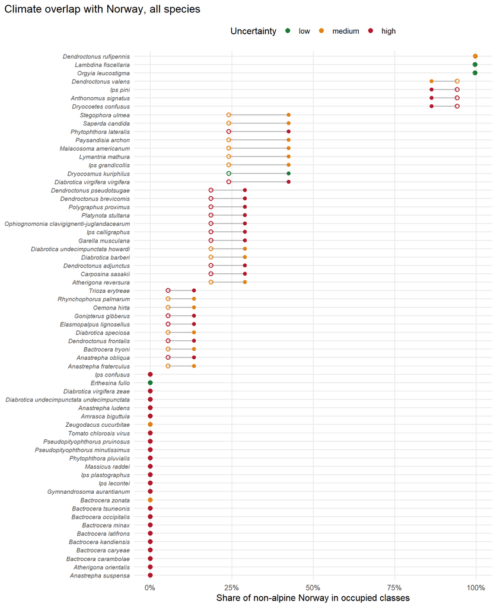

Share of non-alpine Norway in each species’ occupied classes, 1991–2020 (open circle) to 2041–2070 SSP5-8.5 (filled). Colour gives the uncertainty rating of the class list.

```r
unc_cols <- c(low = "#1b7837", medium = "#e08214", high = "#b2182b")

ggplot(overlap, aes(y = reorder(scientificName, pmax(now, future)))) +
  geom_segment(aes(x = now, xend = future, yend = reorder(scientificName, pmax(now, future))),
               colour = "grey70") +
  geom_point(aes(x = now, colour = uncertainty), shape = 21, size = 2, stroke = 0.9) +
  geom_point(aes(x = future, colour = uncertainty), size = 2) +
  scale_colour_manual(values = unc_cols, name = "Uncertainty") +
  scale_x_continuous(labels = scales::percent, limits = c(0, 1)) +
  labs(x = "Share of non-alpine Norway in occupied classes", y = NULL,
       title = "Climate overlap with Norway, all species") +
  theme(axis.text.y = element_text(face = "italic", size = 8),
        legend.position = "top")
```

```r
grp <- overlap |>
  mutate(group = case_when(now > 0.5 ~ "dfc",
                           now == 0 & future == 0 ~ "none",
                           future > now ~ "rising",
                           TRUE ~ "falling")) |>
  count(group) |>
  with(setNames(n, group))
```

The species fall into three groups:

- **7 species** occupy **Dfc** and overlap with more than half of Norway already.
- **31 species** occupy **Dfb** and/or **Cfb** but not Dfc. Their overlap is modest today and grows by mid-century as those classes expand.
- **19 species** have **0 %** in both periods. They are restricted to classes absent from non-alpine Norway, so the Köppen-Geiger evidence argues against establishment outdoors.

A further 6 species share only marginal classes with Norway today, such as the subpolar oceanic Cfc. Those classes all but disappear by 2041–2070, so a warmer climate does not automatically mean a higher overlap.

### 4.3 Supporting indicators

The `species` table carries further evidence an assessor can cite:

| Column | Meaning |
| --- | --- |
| `nCellsNorway`, `nCellsNordic`, `nordicCountries` | Cells already recorded in Norway or the Nordic countries (NO, SE, FI, DK) |
| `nCellsEurope` | Cells in Europe (Russia west of 60° E) |
| `lat95` | 95th percentile of absolute latitude of occupied-class cells, a poleward edge robust to stray points |
| `borealOccupied` | Whether any cold-summer class (Dfc, Dfd, Dwc, Dwd, Dsc, Dsd) is occupied |
| `pctCellsSince2000` | Share of cells with a record since 2000, which flags ranges known only from old data |

### 4.4 Uncertainty: class stability

More records could reveal further occupied classes, so a class list from 30 cells is less trustworthy than one from 20,000. To quantify this, the pipeline draws 100 random halves of each species’ cells. It applies the occupancy rule to each half, with the absolute floor halved, and records how often the occupied classes *that occur in Norway* match the full-data result. Instability in a tropical class does not matter for Norway, so it is ignored.

The rating combines stability with sample size:

- **low:** ≥ 2000 cells and stability ≥ 0.9
- **medium:** ≥ 200 cells and stability ≥ 0.5
- **high:** everything else

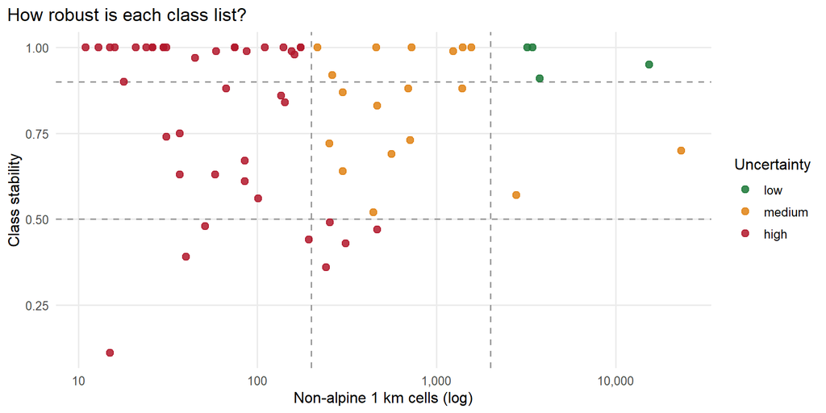

Class stability against sample size. Dashed lines mark the rating thresholds.

```r
ggplot(overlap, aes(cells, classStability, colour = uncertainty)) +
  geom_vline(xintercept = as.numeric(build[c("uncMediumCells", "uncLowCells")]),
             linetype = 2, colour = "grey60") +
  geom_hline(yintercept = c(0.5, 0.9), linetype = 2, colour = "grey60") +
  geom_point(size = 2.4, alpha = 0.85) +
  scale_x_log10(labels = scales::label_comma()) +
  scale_colour_manual(values = unc_cols, name = "Uncertainty") +
  labs(x = "Non-alpine 1 km cells (log)", y = "Class stability",
       title = "How robust is each class list?")
```

```r
knitr::kable(count(overlap, uncertainty, name = "Species"))
```

| uncertainty | Species |
| --- | --- |
| low | 4 |
| medium | 18 |
| high | 41 |

The many *high* ratings are expected. Most quarantine pests are rare in GBIF, which is part of why they are quarantine pests. For these species, the Köppen-Geiger evidence should be weighed lightly against literature on thermal requirements.

### 4.5 Data support per class

The stability rating covers the species as a whole, but within one species the occupied classes can rest on very different amounts of data. A class with 486 cells and a class with 21 cells both count as occupied. Each occupied class therefore also gets a **data support** level, taken directly from its number of 1 km cells. No model is involved, only counts already in `pestKgClasses`.

How many levels, and where to break? I compared 3, 4 and 5 levels, each with two kinds of breaks:

- **Quantile:** equal numbers of classes per level.
- **Fisher natural breaks:** the partition that best separates log cell counts.

Each break set is also tested rounded to readable numbers. Two scores decide between them:

- **GVF** (goodness of variance fit): how well the levels separate the counts, where 1 is perfect.
- **Stability:** each species’ cells are resampled 500 times, and stability is the share of resamples in which a class keeps its level. Dropping below the occupancy rule counts as a change. The same score is also reported for Norway’s three main classes alone, along with the stability of the weakest level.

```r
bins <- compare_support_bins(DB, B = 500)
bins |>
  mutate(across(c(GVF, stability, stabNorway, weakestLevel), ~ round(.x, 2))) |>
  rename(Levels = levels, Method = method, `Breaks (cells)` = breaks,
         Stability = stability, `Stability (Dfc/Dfb/Cfb)` = stabNorway,
         `Weakest level` = weakestLevel, `Classes per level` = perLevel) |>
  knitr::kable()
```

| Levels | Method | Breaks (cells) | GVF | Stability | Stability (Dfc/Dfb/Cfb) | Weakest level | Classes per level |
| --- | --- | --- | --- | --- | --- | --- | --- |
| 3 | quantile | 5-11, 12-41, 42+ | 0.72 | 0.85 | 0.86 | 0.70 | 101 / 109 / 106 |
| 3 | quantile rounded | 5-11, 12-39, 40+ | 0.72 | 0.85 | 0.86 | 0.70 | 101 / 106 / 109 |
| 3 | fisher | 5-23, 24-190, 191+ | 0.83 | 0.90 | 0.92 | 0.86 | 168 / 111 / 37 |
| 3 | fisher rounded | 5-24, 25-199, 200+ | 0.83 | 0.90 | 0.92 | 0.87 | 169 / 110 / 37 |
| 4 | quantile | 5-9, 10-20, 21-63, 64+ | 0.80 | 0.80 | 0.82 | 0.62 | 71 / 83 / 82 / 80 |
| 4 | quantile rounded | 5-9, 10-19, 20-59, 60+ | 0.79 | 0.79 | 0.82 | 0.62 | 71 / 80 / 82 / 83 |
| 4 | fisher | 5-16, 17-70, 71-678, 679+ | 0.91 | 0.88 | 0.87 | 0.82 | 133 / 109 / 60 / 14 |
| 4 | fisher rounded | 5-14, 15-74, 75-749, 750+ | 0.91 | 0.88 | 0.87 | 0.79 | 124 / 121 / 57 / 14 |
| 5 | quantile | 5-8, 9-15, 16-30, 31-88, 89+ | 0.84 | 0.77 | 0.80 | 0.55 | 62 / 64 / 63 / 63 / 64 |
| 5 | quantile rounded | 5-9, 10-14, 15-29, 30-99, 100+ | 0.85 | 0.77 | 0.80 | 0.52 | 71 / 53 / 64 / 68 / 60 |
| 5 | fisher | 5-13, 14-41, 42-160, 161-1567, 1568+ | 0.94 | 0.86 | 0.87 | 0.76 | 118 / 92 / 66 / 31 / 9 |
| 5 | fisher rounded | 5-14, 15-39, 40-149, 150-1499, 1500+ | 0.94 | 0.86 | 0.87 | 0.79 | 124 / 83 / 67 / 33 / 9 |

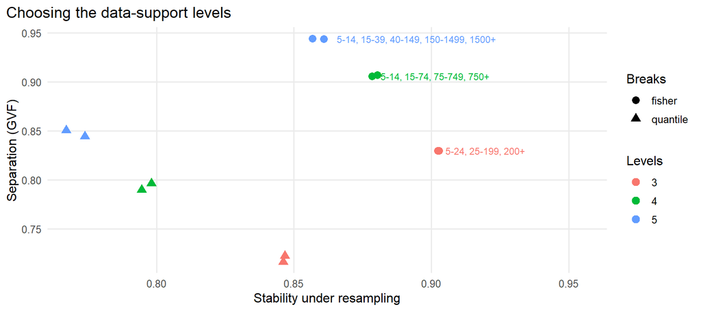

Separation (GVF) against stability for each candidate. Up and right is better.

```r
ggplot(bins, aes(stability, GVF, colour = factor(levels), shape = sub(" rounded", "", method))) +
  geom_point(size = 3) +
  geom_text(data = filter(bins, method == "fisher rounded"),
            aes(label = breaks), hjust = -0.08, size = 3, show.legend = FALSE) +
  scale_x_continuous(expand = expansion(c(0.05, 0.45))) +
  labs(x = "Stability under resampling", y = "Separation (GVF)",
       colour = "Levels", shape = "Breaks",
       title = "Choosing the data-support levels")
```

Fisher breaks beat quantiles at every number of levels, on both scores. Quantile levels slice the crowded low end (5–20 cells) thinly, and classes flip between them easily. More levels separate better but are less stable. Five levels also leave only 9 classes in the top level.

- high: 200 or more cells;
- medium: 25–199 cells;
- low: 5–24 cells.

These values are set in `R/support.R` and used by the app and these documents. Classes under 5 cells are not occupied and get no level.

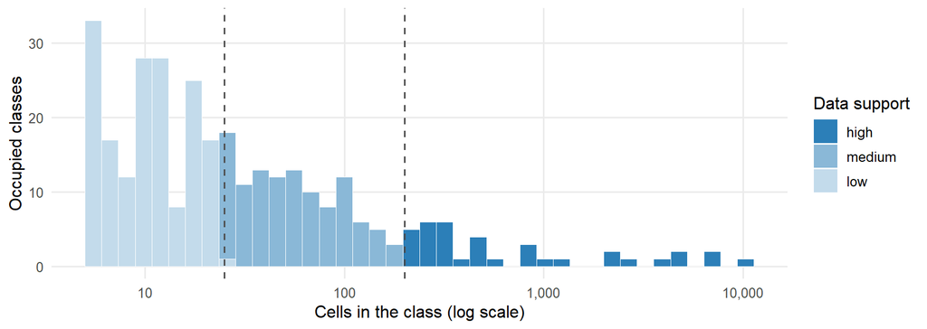

Cells per occupied class across all species, with the data-support breaks.

```r
occ_all <- q("SELECT kgCode, nCells FROM occupiedKgClasses") |>
  mutate(support = factor(SUPPORT_NAMES[support_level(nCells)], SUPPORT_NAMES))
ggplot(occ_all, aes(nCells, fill = support)) +
  geom_histogram(bins = 40, boundary = log10(5), colour = "white", linewidth = 0.2) +
  geom_vline(xintercept = SUPPORT_BREAKS, linetype = 2, colour = "grey30") +
  scale_x_log10(labels = scales::label_comma()) +
  scale_fill_manual(values = tint("#2c7fb8", SUPPORT_TINT), name = "Data support") +
  labs(x = "Cells in the class (log scale)", y = "Occupied classes")
```

On maps, data support is drawn as a **tint**: each class keeps its Köppen-Geiger colour, mixed with 45 % or 72 % white for medium or low support. The legend is a grid of classes against support levels, like a bivariate map legend.

The levels count cells, not independent sites. Thirty cells from one survey weigh the same as thirty cells spread over a continent.

## 5 Worked example

```r
EPPO <- "LYMAMA"
sp   <- filter(overlap, eppoCode == EPPO)
pts  <- q("SELECT * FROM occurrences WHERE eppoCode = ?", list(EPPO))
cls  <- q("SELECT p.kgCode, p.nCells, o.kgCode IS NOT NULL AS occupied,
                  n.proportion AS norway, f.proportion AS norwayFuture
           FROM pestKgClasses p
           LEFT JOIN occupiedKgClasses o USING (eppoCode, kgCode)
           LEFT JOIN kgNorway n USING (kgCode)
           LEFT JOIN kgNorwayFuture f USING (kgCode)
           WHERE p.eppoCode = ? ORDER BY p.nCells DESC", list(EPPO))
```

*Lymantria mathura* (LYMAMA) has 1,391 cleaned cells and a class stability of 0.88, which gives an uncertainty rating of **medium**.

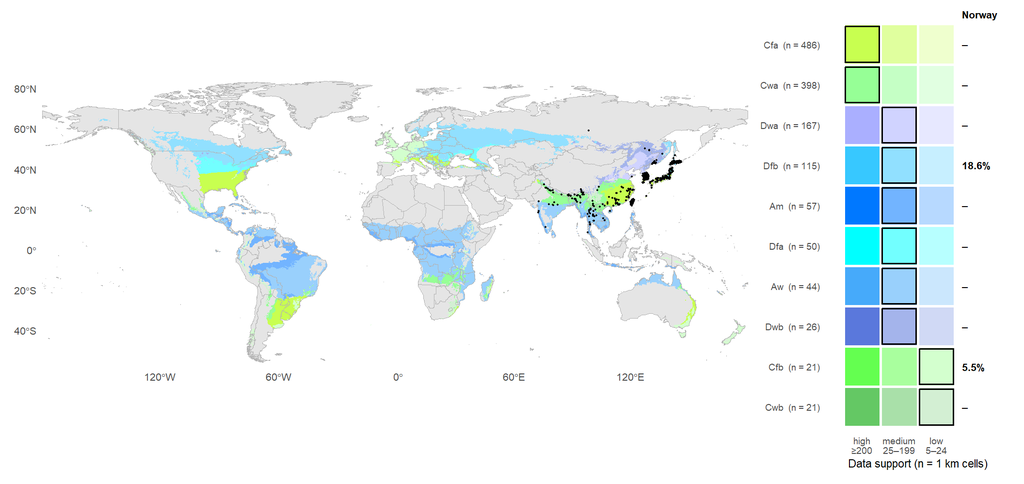

Occupied Köppen-Geiger classes (1991–2020), tinted by data support, with cleaned GBIF cells. The same map and legend as in the app.

```r
support_map(DB, "../koppen_geiger_0p1.tif", EPPO, title = FALSE)
```

```r
cls |>
  left_join(select(legend, kgCode, kgLabel), by = "kgCode") |>
  transmute(Class = kgCode, Climate = kgLabel, Cells = nCells,
            Occupied = if_else(occupied == 1, "✓", ""),
            Support = if_else(occupied == 1, SUPPORT_NAMES[support_level(nCells)], ""),
            `Norway 1991–2020` = scales::percent(coalesce(norway, 0), 0.1),
            `Norway 2041–2070` = scales::percent(coalesce(norwayFuture, 0), 0.1)) |>
  knitr::kable()
```

| Class | Climate | Cells | Occupied | Support | Norway 1991–2020 | Norway 2041–2070 |
| --- | --- | --- | --- | --- | --- | --- |
| Cfa | Temperate, no dry season, hot summer | 486 | ✓ | high | 0.0% | 0.0% |
| Cwa | Temperate, dry winter, hot summer | 398 | ✓ | high | 0.0% | 0.0% |
| Dwa | Cold, dry winter, hot summer | 167 | ✓ | medium | 0.0% | 0.0% |
| Dfb | Cold, no dry season, warm summer | 115 | ✓ | medium | 18.6% | 29.0% |
| Am | Tropical, monsoon | 57 | ✓ | medium | 0.0% | 0.0% |
| Dfa | Cold, no dry season, hot summer | 50 | ✓ | medium | 0.0% | 0.0% |
| Aw | Tropical, savannah | 44 | ✓ | medium | 0.0% | 0.0% |
| Dwb | Cold, dry winter, warm summer | 26 | ✓ | medium | 0.0% | 0.0% |
| Cfb | Temperate, no dry season, warm summer | 21 | ✓ | low | 5.5% | 13.4% |
| Cwb | Temperate, dry winter, warm summer | 21 | ✓ | low | 0.0% | 0.0% |
| Af | Tropical, rainforest | 3 |  |  | 0.0% | 0.0% |
| Dfc | Cold, no dry season, cold summer | 3 |  |  | 75.6% | 57.3% |

In the occupied classes this gives an overlap of **24.0%** of non-alpine Norway today and **42.5%** in 2041–2070. The two shares do not rest on equal data. Dfb has medium support (115 cells), while Cfb, which covers Norway’s west coast, has low support (21 cells). An EST1 justification could cite the shared classes, their area and their data support. It should also check `lat95` (43.3°) and any Nordic records (0 cells) as supporting evidence.

To reproduce this for another species, change `EPPO` above or pick the species in the app.

## 6 Limitations

- **Classes are coarse.** One Köppen-Geiger class spans a wide range of winter minima and degree-days. Dfc in Siberia and Dfc on the Norwegian coast differ in exactly the variables (frost severity, season length) that often limit pests. A shared class means *not excluded*, not *suitable*.
- **The realised range understates the fundamental niche.** A pest absent from a class may be limited by dispersal, hosts or recent arrival rather than climate. Shares are therefore conservative for spreading invaders, and the `pctCellsSince2000` column helps to flag them.
- **Sampling bias persists.** Thinning to 1 km does not correct for whole regions being under-sampled, such as much of Asia and Africa in GBIF. Classes typical of poorly sampled regions are under-represented.
- **Protected cultivation.** `MANAGED` records are dropped, but greenhouse populations are often not flagged in GBIF. Some records in cold classes may be glasshouse records.
- **Taxonomy.** Pathovars and other infraspecific taxa missing from the GBIF backbone are skipped rather than resolved to the species, which would inflate the range. Synonym resolution depends on the GBIF backbone.
- **One scenario.** SSP5-8.5 is a high-end scenario and is used here as a reasonable worst case, not a forecast.
- **Thresholds are judgements.** The occupancy rule and uncertainty cut-offs are explicit and stored in `buildInfo`, but they are not calibrated against known establishment outcomes. Validation against pests with documented establishment or failure in Fennoscandia is the obvious next step.

For high-stakes assessments, follow up a large Norway overlap with process-based modelling (CLIMEX) or a correlative SDM on bioclimatic variables. Both use the cleaned, thinned records in `occurrences` as their starting point.

## 7 Reproducibility

```r
knitr::kable(q("SELECT key AS Setting, value AS Value FROM buildInfo"))
```

| Setting | Value |
| --- | --- |
| buildDate | 2026-10-14T08:51:49 |
| kgSource | Beck et al. 2023, Scientific Data, 1991-2020 |
| kgRaster | koppen_geiger_0p00833333.tif |
| gbifSource | GBIF.org occurrence search API (rgbif::occ_data); fetch date = cache file dates |
| speciesFile | C:/Users/dafl/Downloads/master_species.xlsx |
| maxUncertaintyM | 10000 |
| droppedBasis | FOSSIL_SPECIMEN, LIVING_SPECIMEN |
| droppedEstablishment | MANAGED |
| ccTests | capitals, centroids, equal, gbif, institutions, zeros |
| excludedKg | ET, EF |
| occMinCells | 5 |
| occMinShare | 0.001 |
| nordic | NO, SE, FI, DK |
| borealKg | Dfc, Dfd, Dwc, Dwd, Dsc, Dsd |
| stabRuns | 100 |
| uncMediumCells | 200 |
| uncLowCells | 2000 |
| kgFuture | 2041-2070, SSP5-8.5 |

The database is rebuilt with `kg_db.R`. GBIF downloads are cached per species in `gbif_cache/`, so a rebuild with different thresholds needs no network access. Render this vignette from the `vignettes/` folder with `quarto render kg_viewer.qmd`.

## 8 References

Baker, Richard H. A., Claire E. Sansford, Claire H. Jarvis, Richard J. C. Cannon, Alan MacLeod, and Keith F. A. Walters. 2000. “The Role of Climatic Mapping in Predicting the Potential Geographical Distribution of Non-Indigenous Pests Under Current and Future Climates.” *Agriculture, Ecosystems & Environment* 82 (1–3): 57–71. https://doi.org/10.1016/S0167-8809(00)00216-4.

Beck, Hylke E., Tim R. McVicar, Noemi Vergopolan, et al. 2023. “High-Resolution (1 Km) Köppen-Geiger Maps for 1901–2099 Based on Constrained CMIP6 Projections.” *Scientific Data* 10: 724. https://doi.org/10.1038/s41597-023-02549-6.

EFSA Panel on Plant Health (PLH). 2018. “Guidance on Quantitative Pest Risk Assessment.” *EFSA Journal* 16 (8): 5350. https://doi.org/10.2903/j.efsa.2018.5350.

Elith, Jane, and John R. Leathwick. 2009. “Species Distribution Models: Ecological Explanation and Prediction Across Space and Time.” *Annual Review of Ecology, Evolution, and Systematics* 40: 677–97. https://doi.org/10.1146/annurev.ecolsys.110308.120159.

Heikkilä, Jaakko, Juha Tuomola, Eija Pouta, and Salla Hannunen. 2016. “FinnPRIO: A Model for Ranking Invasive Plant Pests Based on Risk.” *Biological Invasions* 18 (7): 1827–42. https://doi.org/10.1007/s10530-016-1123-6.

Kottek, Markus, Jürgen Grieser, Christoph Beck, Bruno Rudolf, and Franz Rubel. 2006. “World Map of the Köppen-Geiger Climate Classification Updated.” *Meteorologische Zeitschrift* 15 (3): 259–63. https://doi.org/10.1127/0941-2948/2006/0130.

Sutherst, Robert W., and Gunter F. Maywald. 1985. “A Computerised System for Matching Climates in Ecology.” *Agriculture, Ecosystems & Environment* 13 (3–4): 281–99. https://doi.org/10.1016/0167-8809(85)90016-7.

Zizka, Alexander, Daniele Silvestro, Tobias Andermann, et al. 2019. “CoordinateCleaner: Standardized Cleaning of Occurrence Records from Biological Collection Databases.” *Methods in Ecology and Evolution* 10 (5): 744–51. https://doi.org/10.1111/2041-210X.13152.